# Sampled-Mode Workflow: scRNA-seq without Spatial Coordinates

2026-04-20

## Overview

Ligand–receptor-mediated (LRM) signaling inference requires defining which cell pairs to score. When spatial coordinates are available, physical proximity provides a principled basis for that definition. Without coordinates — as in most droplet-based scRNA-seq experiments — the choice is less obvious.

The naive approach of scoring every possible cell pair is computationally intractable: 14,000 cells produce nearly 200 million ordered pairs, each requiring scores for hundreds of LRM pairs. More importantly, most of those pairs are biologically uninterpretable because the cells never coexisted in the same microenvironment.

NICHESv2’s **sampled mode** solves this by drawing a stratified random sample of cell pairs within each cell-type stratum. The sampling is reproducible (fixed seed), keeps the cell-type composition of the data intact, and produces an edge list compact enough for downstream analysis. The result is a `NICHESObject` with the same slot structure as spatial mode, enabling identical downstream workflows.

## Setup

```r
library(NICHESv2)
library(SeuratData)   # github.com/satijalab/seurat-data
library(SeuratObject)
library(ggplot2)
library(data.table)
```

Install and load the `ifnb` dataset if you have not done so already:

```r
# Run once to download (~50 MB)
# SeuratData::InstallData("ifnb")

data("ifnb")   # loads the Seurat object into your session
ifnb <- UpdateSeuratObject(ifnb)    # required: updates serialized object to current SeuratObject version
ifnb
```

```
#> An object of class Seurat
#> 14053 features across 13999 samples within 1 assay
#> Active assay: RNA (14053 features, 0 variable features)
```

## Step 1 — Ingest from Seurat

`extract_NICHESInputs_Seurat()` extracts the raw count matrix and cell metadata from a Seurat object. It detects V4 and V5 assay structures automatically, so no manual conversion is needed.

```r
inputs <- extract_NICHESInputs_Seurat(
  seurat.obj = ifnb,
  assay      = "RNA",
  layer      = "counts",
  verbose    = TRUE
)

dim(inputs$count.mtx)
```

```
#> [1] 14053 13999       # genes × cells
```

```r
colnames(inputs$meta.data)
```

```
#> [1] "orig.ident"          "nCount_RNA"          "nFeature_RNA"
#> [4] "stim"                "seurat_annotations"
```

The `ifnb` metadata includes two columns we will use downstream:

- **`stim`** — experimental condition (`CTRL` or `STIM`); used as `sample.col`
- **`seurat_annotations`** — cell type labels (e.g. `CD14 Mono`, `CD8 T`); used as `cell.type.col`

```r
table(inputs$meta.data$stim)
```

```
#> CTRL STIM
#> 6548 7451
```

## Step 2 — Why sample splitting matters

The `ifnb` dataset contains cells from two independent conditions profiled in separate batches. Constructing edges across conditions would pair a CTRL cell with a STIM cell — a combination that never occurred in any biological sample. Such cross-condition edges inflate apparent connectivity and make the results uninterpretable.

Setting `sample.col = "stim"` instructs NICHESv2 to build edges **within** each condition independently, then merge the resulting objects. Every edge in the final NICHESObject is guaranteed to connect two cells from the same condition.

```r
# Without sample.col: edges are built across all 13,999 cells simultaneously.
# CTRL cells can be paired with STIM cells — biologically meaningless.
#
# With sample.col = "stim": NICHESv2 processes CTRL (6,548 cells) and
# STIM (7,451 cells) separately, then merges. All edges are within-condition.
#
# Rule of thumb: if your experiment has multiple samples, donors, replicates,
# capture areas, or conditions, always set sample.col.
```

## Step 3 — Build the NICHESObject

```r
niches.ifnb <- create_NICHESObject(
  count.mtx     = inputs$count.mtx,
  meta.data     = inputs$meta.data,
  LRM.db        = load_LRM_database("fantom5", species = "human"),
  mode          = "sampled",
  species       = "human",
  sample.col    = "stim",
  cell.type.col = "seurat_annotations",
  method        = "product",
  n.cores       = 4L,
  verbose       = TRUE
)
```

`load_LRM_database("fantom5", species = "human")` loads the bundled FANTOM5 ligand–receptor database for human — no internet connection or additional packages required.

## Step 4 — Inspect the result

```r
print(niches.ifnb)
```

```
#> -- NICHESObject --------------------------------------------
#>   Cells        : 13999  (13999 non-empty)
#>   Genes        : 14053  (14044 valid)
#>   Edges        : 87957  (84637 non-empty)
#>   LRM pairs    : 820  (637 valid)
#>   Segmentation : none
#>
#>   Slot summary:
#>     $cell.list     -- character vector of cell barcodes
#>     $cell.data     -- (cell, gene, score, score.norm) [sparse]
#>     $cell.meta     -- per-cell metadata
#>     $edge.list     -- (edge, SendingCell, ReceivingCell)
#>     $edge.data     -- (edge, LRM, score, score.norm) [sparse]
#>     $edge.meta     -- per-edge metadata with Sending/Receiving/Joint cols
#>     $neighborhood.* -- reserved (NULL)
#>     $gene.list     -- character vector of gene names
#>     $gene.meta     -- per-gene metadata
#>     $LRM.list      -- character vector of 'ligand|receptor' pairs
#>     $LRM.meta      -- per-LRM metadata
#>     $segmentation  -- sf object of cell polygons, or NULL
#> ------------------------------------------------------------
```

Each **edge** is a directed cell pair (`SendingCell|ReceivingCell`). The `$edge.data` slot stores LRM scores in sparse long format — only non-zero signal is recorded:

```r
head(niches.ifnb$edge.data, 3)
```

```
#> Key: <edge, LRM>
#>                                 edge        LRM score  score.norm
#>                               <char>     <char> <num>       <num>
#> 1: AAACATACATTTCC.1|CGCACGGACTATGG.1 ANXA1|FPR3     6 0.008559201
#> 2: AAACATACATTTCC.1|CGCACGGACTATGG.1  B2M|HLA-F    95 0.135520685
#> 3: AAACATACATTTCC.1|CGCACGGACTATGG.1  CCL2|CCR1     6 0.008559201
```

The `$edge.meta` slot joins the cell metadata of both partners onto every edge. Cell-type annotations propagate as `Sending.*`, `Receiving.*`, and `Joint.*` columns:

```r
head(
  niches.ifnb$edge.meta[, .(
    edge,
    Sending.seurat_annotations,
    Receiving.seurat_annotations,
    Joint.seurat_annotations,
    Joint.stim
  )],
  3
)
```

```
#> Key: <edge>
#>                                  edge Sending.seurat_annotations
#>                                <char>                     <fctr>
#> 1: AAACATACATTTCC.1|CGCACGGACTATGG.1                  CD14 Mono
#> 2: AAACATACCAAGCT.1|AAATTCGATAGACC.1                      CD8 T
#> 3: AAACATACCAAGCT.1|AAGGCTACAAGGGC.1                      CD8 T
#>    Receiving.seurat_annotations   Joint.seurat_annotations Joint.stim
#>                          <fctr>                     <char>     <char>
#> 1:                    CD14 Mono      CD14 Mono|CD14 Mono  CTRL|CTRL
#> 2:                           Mk                  CD8 T|Mk  STIM|STIM
#> 3:                            B                   CD8 T|B  STIM|STIM
```

## Step 5 — Pseudobulk connectivity

Single-cell edge scores can be aggregated to the cell-type level with `compute_PseudoBulk_Connectivity()`. This function collapses expression to pseudobulk profiles per cell type, scores all LRM pairs across all type–type combinations, and returns a flat `data.table`:

```r
pb <- compute_PseudoBulk_Connectivity(
  count.mtx     = inputs$count.mtx,
  meta.data     = inputs$meta.data,
  LRM.db        = load_LRM_database("fantom5", species = "human"),
  cell.type.col = "seurat_annotations",
  method        = "product",
  n.cores       = 4L,
  verbose       = TRUE
)

dim(pb)
```

```
#> [1] 63858     7
```

```r
head(pb[, .(SendingType, ReceivingType, LRM, score, score.norm)], 5)
```

[output not shown]

Note that `compute_PseudoBulk_Connectivity()` operates directly on the count matrix and metadata — it does not require a `NICHESObject` as input. This makes it straightforward to run as a standalone summary step before or after sampled-mode inference.

### Visualising cell-type connectivity

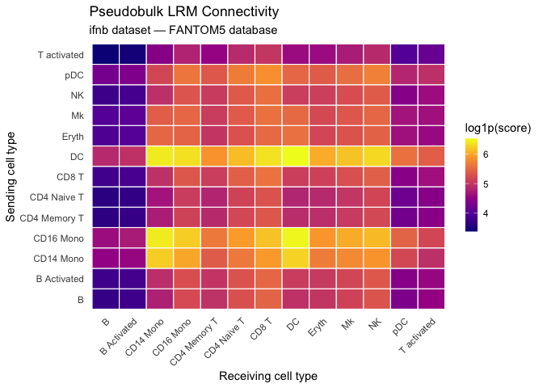

```r
# Sum raw scores across LRM pairs per type pair — score.norm is within-pair
# proportional and sums to ~1 per pair, making it unsuitable for cross-pair comparison.
pb.agg <- pb[, .(total.score = sum(score)),
             by = .(SendingType, ReceivingType)]

ggplot(pb.agg, aes(x = ReceivingType, y = SendingType,
                   fill = log1p(total.score))) +
  geom_tile(colour = "white", linewidth = 0.4) +
  scale_fill_viridis_c(option = "plasma", name = "log1p(score)") +
  labs(
    title    = "Pseudobulk LRM Connectivity",
    subtitle = "ifnb dataset — FANTOM5 database",
    x        = "Receiving cell type",
    y        = "Sending cell type"
  ) +
  theme_minimal(base_size = 11) +
  theme(
    axis.text.x      = element_text(angle = 45, hjust = 1),
    panel.grid       = element_blank(),
    legend.key.width = unit(0.4, "cm")
  )
```

## What’s next

This vignette covered the sampled-mode workflow for annotated scRNA-seq data without spatial coordinates. Because sampled mode does not assign physical positions to cells, in-situ plotting is not available — `CellToCell_InSitu()` requires spatial coordinates in `$cell.meta`.

For spatially resolved data (Visium, MERFISH, Xenium, etc.), see the next vignette: **Spatial-Mode Workflow**, which covers radius parameter selection with `Explore_Radius_Neighborhood()` and in-situ LRM connectivity maps with `CellToCell_InSitu_Single_LRM()`.